# Quantium DA Task1

Santosh Reddy Edulapalle

2023-02-13

#### Load required libraries

```r
library(data.table)
library(ggplot2)
library(ggmosaic)
library(readr)
library(stringr)
library(dplyr)
```

#### Loading the dataset

```r
#install.packages('readxl')
library('readxl')
trans <- read_excel('QVI_transaction_data.xlsx')
```

## Exploratory data analysis

The first step in any analysis is to first understand the data. Let’s take a look at each of the datasets provided. ### Examine transaction data

```r
#showing head ( top 10 rows)
head(trans)
```

```
## # A tibble: 6 × 8
##    DATE STORE_NBR LYLTY_CARD_NBR TXN_ID PROD_NBR PROD_NAME       PROD_…¹ TOT_S…²
##   <dbl>     <dbl>          <dbl>  <dbl>    <dbl> <chr>             <dbl>   <dbl>
## 1 43390         1           1000      1        5 Natural Chip  …       2     6
## 2 43599         1           1307    348       66 CCs Nacho Chee…       3     6.3
## 3 43605         1           1343    383       61 Smiths Crinkle…       2     2.9
## 4 43329         2           2373    974       69 Smiths Chip Th…       5    15
## 5 43330         2           2426   1038      108 Kettle Tortill…       3    13.8
## 6 43604         4           4074   2982       57 Old El Paso Sa…       1     5.1
## # … with abbreviated variable names ¹PROD_QTY, ²TOT_SALES
```

```r
#showing summary
summary(trans)
```

```
##       DATE         STORE_NBR     LYLTY_CARD_NBR        TXN_ID
##  Min.   :43282   Min.   :  1.0   Min.   :   1000   Min.   :      1
##  1st Qu.:43373   1st Qu.: 70.0   1st Qu.:  70021   1st Qu.:  67602
##  Median :43464   Median :130.0   Median : 130358   Median : 135138
##  Mean   :43464   Mean   :135.1   Mean   : 135550   Mean   : 135158
##  3rd Qu.:43555   3rd Qu.:203.0   3rd Qu.: 203094   3rd Qu.: 202701
##  Max.   :43646   Max.   :272.0   Max.   :2373711   Max.   :2415841
##     PROD_NBR       PROD_NAME            PROD_QTY         TOT_SALES
##  Min.   :  1.00   Length:264836      Min.   :  1.000   Min.   :  1.500
##  1st Qu.: 28.00   Class :character   1st Qu.:  2.000   1st Qu.:  5.400
##  Median : 56.00   Mode  :character   Median :  2.000   Median :  7.400
##  Mean   : 56.58                      Mean   :  1.907   Mean   :  7.304
##  3rd Qu.: 85.00                      3rd Qu.:  2.000   3rd Qu.:  9.200
##  Max.   :114.00                      Max.   :200.000   Max.   :650.000
```

```r
#showing high level structure
str(trans)
```

```
## tibble [264,836 × 8] (S3: tbl_df/tbl/data.frame)
##  $ DATE          : num [1:264836] 43390 43599 43605 43329 43330 ...
##  $ STORE_NBR     : num [1:264836] 1 1 1 2 2 4 4 4 5 7 ...
##  $ LYLTY_CARD_NBR: num [1:264836] 1000 1307 1343 2373 2426 ...
##  $ TXN_ID        : num [1:264836] 1 348 383 974 1038 ...
##  $ PROD_NBR      : num [1:264836] 5 66 61 69 108 57 16 24 42 52 ...
##  $ PROD_NAME     : chr [1:264836] "Natural Chip        Compny SeaSalt175g" "CCs Nacho Cheese    175g" "Smiths Crinkle Cut  Chips Chicken 170g" "Smiths Chip Thinly  S/Cream&Onion 175g" ...
##  $ PROD_QTY      : num [1:264836] 2 3 2 5 3 1 1 1 1 2 ...
##  $ TOT_SALES     : num [1:264836] 6 6.3 2.9 15 13.8 5.1 5.7 3.6 3.9 7.2 ...
```

#### Convert DATE column to a date format

We can see that the DATE type is DOUBLE We need to convert it to DATE type CSV and Excel integer dates begin on 30 Dec 1899

```r
typeof(trans$DATE)
```

```
## [1] "double"
```

```r
trans$DATE <- as.Date(trans$DATE,origin = '1899-12-30')
typeof(trans$DATE)
```

```
## [1] "double"
```

```r
#examine structure
str(trans)
```

```
## tibble [264,836 × 8] (S3: tbl_df/tbl/data.frame)
##  $ DATE          : Date[1:264836], format: "2018-10-17" "2019-05-14" ...
##  $ STORE_NBR     : num [1:264836] 1 1 1 2 2 4 4 4 5 7 ...
##  $ LYLTY_CARD_NBR: num [1:264836] 1000 1307 1343 2373 2426 ...
##  $ TXN_ID        : num [1:264836] 1 348 383 974 1038 ...
##  $ PROD_NBR      : num [1:264836] 5 66 61 69 108 57 16 24 42 52 ...
##  $ PROD_NAME     : chr [1:264836] "Natural Chip        Compny SeaSalt175g" "CCs Nacho Cheese    175g" "Smiths Crinkle Cut  Chips Chicken 170g" "Smiths Chip Thinly  S/Cream&Onion 175g" ...
##  $ PROD_QTY      : num [1:264836] 2 3 2 5 3 1 1 1 1 2 ...
##  $ TOT_SALES     : num [1:264836] 6 6.3 2.9 15 13.8 5.1 5.7 3.6 3.9 7.2 ...
```

#### Examine PROD_NAME

Since PROD_NAME is a name given to individual object, we will factorise it and make them into groups.

```r
trans$PROD_NAME_FACTOR <- factor(trans$PROD_NAME)
summary(trans$PROD_NAME_FACTOR)
```

```
##   Kettle Mozzarella   Basil & Pesto 175g
##                                     3304
## Kettle Tortilla ChpsHny&Jlpno Chili 150g
##                                     3296
## Cobs Popd Swt/Chlli &Sr/Cream Chips 110g
##                                     3269
##   Tyrrells Crisps     Ched & Chives 165g
##                                     3268
##           Cobs Popd Sea Salt  Chips 110g
##                                     3265
##             Kettle 135g Swt Pot Sea Salt
##                                     3257
##            Tostitos Splash Of  Lime 175g
##                                     3252
## Infuzions Thai SweetChili PotatoMix 110g
##                                     3242
##   Smiths Crnkle Chip  Orgnl Big Bag 380g
##                                     3233
##     Thins Potato Chips  Hot & Spicy 175g
##                                     3229
## Kettle Sensations   Camembert & Fig 150g
##                                     3219
##  Doritos Corn Chips  Cheese Supreme 170g
##                                     3217
##                 Pringles Barbeque   134g
##                                     3210
##  Doritos Corn Chip Mexican Jalapeno 150g
##                                     3204
##  Kettle Sweet Chilli And Sour Cream 175g
##                                     3200
## Smiths Crinkle Chips Salt & Vinegar 330g
##                                     3197
##           Thins Chips Light&  Tangy 175g
##                                     3188
##         Dorito Corn Chp     Supreme 380g
##                                     3185
##             Pringles Sweet&Spcy BBQ 134g
##                                     3177
##  Infuzions BBQ Rib   Prawn Crackers 110g
##                                     3174
```

[output cut: 145 more lines]

```
##                                     1468
##         WW Crinkle Cut      Chicken 175g
##                                     1467
##  Smiths Crinkle Cut  Chips Original 170g
##                                     1461
## Smiths Thinly       Swt Chli&S/Cream175G
##                                     1461
##   Natural ChipCo      Hony Soy Chckn175g
##                                     1460
## Red Rock Deli SR    Salsa & Mzzrlla 150g
##                                     1458
##     RRD Steak &         Chimuchurri 150g
##                                     1455
##                                  (Other)
##                                    21550
```

```r
summary(trans)
```

```
##       DATE              STORE_NBR     LYLTY_CARD_NBR        TXN_ID
##  Min.   :2018-07-01   Min.   :  1.0   Min.   :   1000   Min.   :      1
##  1st Qu.:2018-09-30   1st Qu.: 70.0   1st Qu.:  70021   1st Qu.:  67602
##  Median :2018-12-30   Median :130.0   Median : 130358   Median : 135138
##  Mean   :2018-12-30   Mean   :135.1   Mean   : 135550   Mean   : 135158
##  3rd Qu.:2019-03-31   3rd Qu.:203.0   3rd Qu.: 203094   3rd Qu.: 202701
##  Max.   :2019-06-30   Max.   :272.0   Max.   :2373711   Max.   :2415841
##
##     PROD_NBR       PROD_NAME            PROD_QTY         TOT_SALES
##  Min.   :  1.00   Length:264836      Min.   :  1.000   Min.   :  1.500
##  1st Qu.: 28.00   Class :character   1st Qu.:  2.000   1st Qu.:  5.400
##  Median : 56.00   Mode  :character   Median :  2.000   Median :  7.400
##  Mean   : 56.58                      Mean   :  1.907   Mean   :  7.304
##  3rd Qu.: 85.00                      3rd Qu.:  2.000   3rd Qu.:  9.200
##  Max.   :114.00                      Max.   :200.000   Max.   :650.000
##
##                                  PROD_NAME_FACTOR
##  Kettle Mozzarella   Basil & Pesto 175g  :  3304
##  Kettle Tortilla ChpsHny&Jlpno Chili 150g:  3296
##  Cobs Popd Swt/Chlli &Sr/Cream Chips 110g:  3269
##  Tyrrells Crisps     Ched & Chives 165g  :  3268
##  Cobs Popd Sea Salt  Chips 110g          :  3265
##  Kettle 135g Swt Pot Sea Salt            :  3257
##  (Other)                                 :245177
```

```r
str(trans)
```

```
## tibble [264,836 × 9] (S3: tbl_df/tbl/data.frame)
##  $ DATE            : Date[1:264836], format: "2018-10-17" "2019-05-14" ...
##  $ STORE_NBR       : num [1:264836] 1 1 1 2 2 4 4 4 5 7 ...
##  $ LYLTY_CARD_NBR  : num [1:264836] 1000 1307 1343 2373 2426 ...
##  $ TXN_ID          : num [1:264836] 1 348 383 974 1038 ...
##  $ PROD_NBR        : num [1:264836] 5 66 61 69 108 57 16 24 42 52 ...
##  $ PROD_NAME       : chr [1:264836] "Natural Chip        Compny SeaSalt175g" "CCs Nacho Cheese    175g" "Smiths Crinkle Cut  Chips Chicken 170g" "Smiths Chip Thinly  S/Cream&Onion 175g" ...
##  $ PROD_QTY        : num [1:264836] 2 3 2 5 3 1 1 1 1 2 ...
##  $ TOT_SALES       : num [1:264836] 6 6.3 2.9 15 13.8 5.1 5.7 3.6 3.9 7.2 ...
##  $ PROD_NAME_FACTOR: Factor w/ 114 levels "Burger Rings 220g",..: 44 2 80 76 43 51 78 23 14 24 ...
```

### Examine product words in PROD_NAME

```r
library(data.table)
productWords <- data.table(unlist(strsplit(unique(trans$PROD_NAME), " ")))
setnames(productWords, 'words')
#productWords
```

### Removing words that contain numerical

```r
numerical.validation <- grepl('[1-9]',productWords[,words])
productWords <- productWords[numerical.validation==FALSE]
#productWords
```

### Removing words that contain special character ‘&’

```r
scAnd.validation <- grepl('&',productWords[,words])
productWords <- productWords[scAnd.validation==FALSE]
```

### Removing words that contain special character ‘/’

```r
sc.validation <- grepl('/',productWords[,words])
productWords <- productWords[sc.validation==FALSE]
```

### Counting frequencies

```r
#factorising words
productWords <- factor(productWords$words)
```

summary

```r
summary(productWords)
```

```
##                   Chips      Smiths     Crinkle         Cut      Kettle
##         234          21          16          14          14          13
##      Cheese        Salt    Original        Chip     Doritos       Salsa
##          12          12          10           9           9           9
##        Corn    Pringles         RRD     Chicken          WW         Sea
##           8           8           8           7           7           6
##        Sour      Chilli      Crisps      Thinly       Thins     Vinegar
##           6           5           5           5           5           5
##       Cream        Deli   Infuzions     Natural         Red        Rock
##           4           4           4           4           4           4
##     Supreme         CCs        Cobs         Dip          El        Lime
##           4           3           3           3           3           3
##        Mild         Old        Paso        Popd  Sensations         Soy
##           3           3           3           3           3           3
##       Sweet      Tomato    Tortilla    Tostitos    Twisties  Woolworths
##           3           3           3           3           3           3
##         And         BBQ      Burger     Cheetos    Cheezels      ChipCo
##           2           2           2           2           2           2
##      Chives      French       Grain       Honey     Lightly      Medium
##           2           2           2           2           2           2
##       Nacho      Potato       Rings      Salted       Smith          SR
##           2           2           2           2           2           2
##         Swt       Tangy        Thai    Tyrrells       Waves       Aioli
##           2           2           2           2           2           1
##       Bacon         Bag       Balls    Barbecue    Barbeque       Basil
##           1           1           1           1           1           1
##       Belly         Big   Bolognese         Box      Btroot   Camembert
##           1           1           1           1           1           1
##        Ched       Chili Chimuchurri    Chipotle       Chnky         Chp
##           1           1           1           1           1           1
##         Chs      Chutny          Co     Coconut      Compny    Crackers
##           1           1           1           1           1           1
##       Crips         Crm         Crn     (Other)
##           1           1           1          70
```

```r
trans <- data.table(trans)
```

#### Remove salsa products

```r
# Remove salsa products
trans[, SALSA := grepl("salsa", tolower(PROD_NAME))]
trans <- trans[SALSA == FALSE, ][, SALSA := NULL]
```

#### Summarise the data to check for nulls and possible outliers

```r
summary(trans)
```

```
##       DATE              STORE_NBR     LYLTY_CARD_NBR        TXN_ID
##  Min.   :2018-07-01   Min.   :  1.0   Min.   :   1000   Min.   :      1
##  1st Qu.:2018-09-30   1st Qu.: 70.0   1st Qu.:  70015   1st Qu.:  67569
##  Median :2018-12-30   Median :130.0   Median : 130367   Median : 135183
##  Mean   :2018-12-30   Mean   :135.1   Mean   : 135531   Mean   : 135131
##  3rd Qu.:2019-03-31   3rd Qu.:203.0   3rd Qu.: 203084   3rd Qu.: 202654
##  Max.   :2019-06-30   Max.   :272.0   Max.   :2373711   Max.   :2415841
##
##     PROD_NBR       PROD_NAME            PROD_QTY         TOT_SALES
##  Min.   :  1.00   Length:246742      Min.   :  1.000   Min.   :  1.700
##  1st Qu.: 26.00   Class :character   1st Qu.:  2.000   1st Qu.:  5.800
##  Median : 53.00   Mode  :character   Median :  2.000   Median :  7.400
##  Mean   : 56.35                      Mean   :  1.908   Mean   :  7.321
##  3rd Qu.: 87.00                      3rd Qu.:  2.000   3rd Qu.:  8.800
##  Max.   :114.00                      Max.   :200.000   Max.   :650.000
##
##                                  PROD_NAME_FACTOR
##  Kettle Mozzarella   Basil & Pesto 175g  :  3304
##  Kettle Tortilla ChpsHny&Jlpno Chili 150g:  3296
##  Cobs Popd Swt/Chlli &Sr/Cream Chips 110g:  3269
##  Tyrrells Crisps     Ched & Chives 165g  :  3268
##  Cobs Popd Sea Salt  Chips 110g          :  3265
##  Kettle 135g Swt Pot Sea Salt            :  3257
##  (Other)                                 :227083
```

### Checking for outliers

By seeing summary of data, we can see that the maximum value of PROD_QTY is more that (3rd quartile + 1.5*IQR)

Lets confirm this with a boxplot

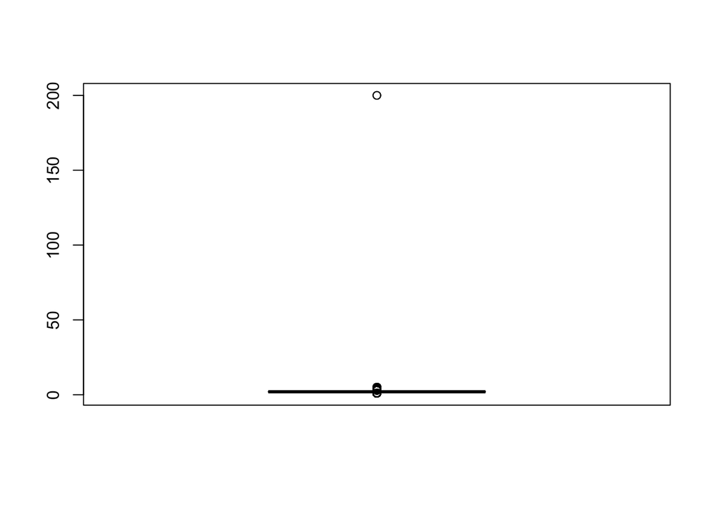

```r
boxplot(trans$PROD_QTY)
```

Yes we can confirm existance of outliers.

```r
library(dplyr)
filter(trans,trans$PROD_QTY==200)
```

```
##          DATE STORE_NBR LYLTY_CARD_NBR TXN_ID PROD_NBR
## 1: 2018-08-19       226         226000 226201        4
## 2: 2019-05-20       226         226000 226210        4
##                           PROD_NAME PROD_QTY TOT_SALES
## 1: Dorito Corn Chp     Supreme 380g      200       650
## 2: Dorito Corn Chp     Supreme 380g      200       650
##                    PROD_NAME_FACTOR
## 1: Dorito Corn Chp     Supreme 380g
## 2: Dorito Corn Chp     Supreme 380g
```

We have 2 records where the PROD_QTY is 200. Both are made by same customer 226000. Let’s see if he has any other transactions

```r
filter(trans,trans$LYLTY_CARD_NBR==226000)
```

```
##          DATE STORE_NBR LYLTY_CARD_NBR TXN_ID PROD_NBR
## 1: 2018-08-19       226         226000 226201        4
## 2: 2019-05-20       226         226000 226210        4
##                           PROD_NAME PROD_QTY TOT_SALES
## 1: Dorito Corn Chp     Supreme 380g      200       650
## 2: Dorito Corn Chp     Supreme 380g      200       650
##                    PROD_NAME_FACTOR
## 1: Dorito Corn Chp     Supreme 380g
## 2: Dorito Corn Chp     Supreme 380g
```

It looks like this customer has only had the two transactions over the year and is not an ordinary retail customer. The customer might be buying chips for commercial purposes instead. We’ll remove this loyalty card number from further analysis.

#### Filter out the customer based on the loyalty card number

Removing customer - 226000 from further analysis

```r
#trans[,trans$LYLTY_CARD_NBR != 226000]
trans <- trans[trans[,trans$LYLTY_CARD_NBR != 226000]]
```

#### Re-examine transaction data

```r
summary(trans)
```

```
##       DATE              STORE_NBR     LYLTY_CARD_NBR        TXN_ID
##  Min.   :2018-07-01   Min.   :  1.0   Min.   :   1000   Min.   :      1
##  1st Qu.:2018-09-30   1st Qu.: 70.0   1st Qu.:  70015   1st Qu.:  67569
##  Median :2018-12-30   Median :130.0   Median : 130367   Median : 135182
##  Mean   :2018-12-30   Mean   :135.1   Mean   : 135530   Mean   : 135130
##  3rd Qu.:2019-03-31   3rd Qu.:203.0   3rd Qu.: 203083   3rd Qu.: 202652
##  Max.   :2019-06-30   Max.   :272.0   Max.   :2373711   Max.   :2415841
##
##     PROD_NBR       PROD_NAME            PROD_QTY       TOT_SALES
##  Min.   :  1.00   Length:246740      Min.   :1.000   Min.   : 1.700
##  1st Qu.: 26.00   Class :character   1st Qu.:2.000   1st Qu.: 5.800
##  Median : 53.00   Mode  :character   Median :2.000   Median : 7.400
##  Mean   : 56.35                      Mean   :1.906   Mean   : 7.316
##  3rd Qu.: 87.00                      3rd Qu.:2.000   3rd Qu.: 8.800
##  Max.   :114.00                      Max.   :5.000   Max.   :29.500
##
##                                  PROD_NAME_FACTOR
##  Kettle Mozzarella   Basil & Pesto 175g  :  3304
##  Kettle Tortilla ChpsHny&Jlpno Chili 150g:  3296
##  Cobs Popd Swt/Chlli &Sr/Cream Chips 110g:  3269
##  Tyrrells Crisps     Ched & Chives 165g  :  3268
##  Cobs Popd Sea Salt  Chips 110g          :  3265
##  Kettle 135g Swt Pot Sea Salt            :  3257
##  (Other)                                 :227081
```

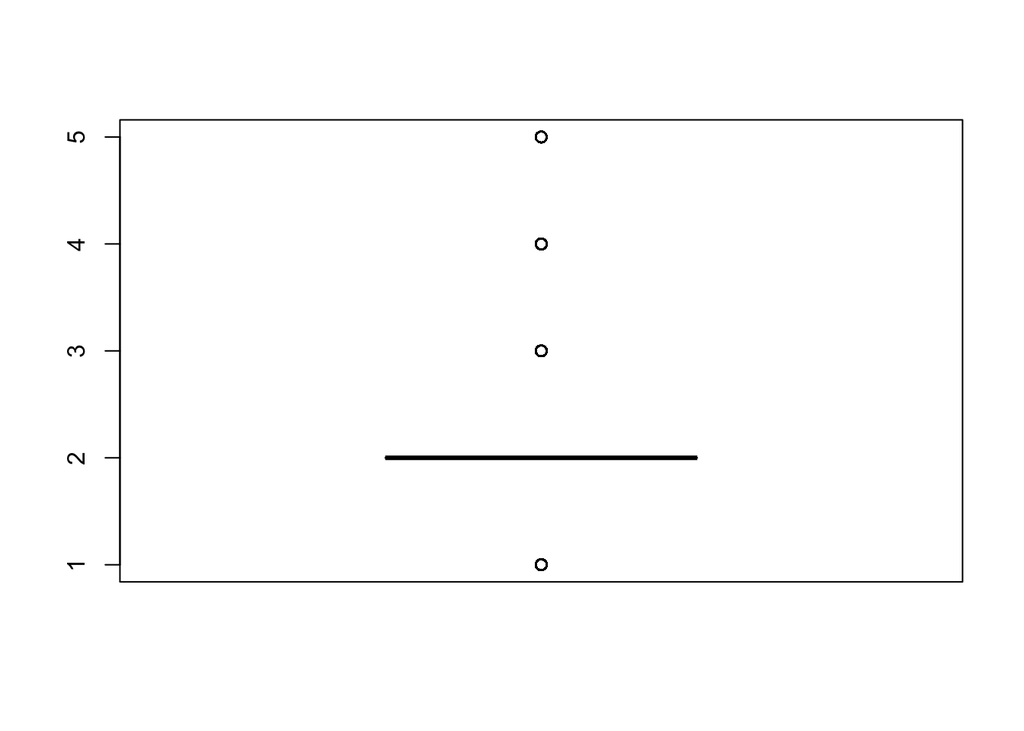

```r
boxplot(trans$PROD_QTY)
```

#### Count the number of transactions by date

Let us factorise the dates

```r
trans$newDATE <- factor(trans$DATE)
```

Summary

```r
summary(trans)
```

```
##       DATE              STORE_NBR     LYLTY_CARD_NBR        TXN_ID
##  Min.   :2018-07-01   Min.   :  1.0   Min.   :   1000   Min.   :      1
##  1st Qu.:2018-09-30   1st Qu.: 70.0   1st Qu.:  70015   1st Qu.:  67569
##  Median :2018-12-30   Median :130.0   Median : 130367   Median : 135182
##  Mean   :2018-12-30   Mean   :135.1   Mean   : 135530   Mean   : 135130
##  3rd Qu.:2019-03-31   3rd Qu.:203.0   3rd Qu.: 203083   3rd Qu.: 202652
##  Max.   :2019-06-30   Max.   :272.0   Max.   :2373711   Max.   :2415841
##
##     PROD_NBR       PROD_NAME            PROD_QTY       TOT_SALES
##  Min.   :  1.00   Length:246740      Min.   :1.000   Min.   : 1.700
##  1st Qu.: 26.00   Class :character   1st Qu.:2.000   1st Qu.: 5.800
##  Median : 53.00   Mode  :character   Median :2.000   Median : 7.400
##  Mean   : 56.35                      Mean   :1.906   Mean   : 7.316
##  3rd Qu.: 87.00                      3rd Qu.:2.000   3rd Qu.: 8.800
##  Max.   :114.00                      Max.   :5.000   Max.   :29.500
##
##                                  PROD_NAME_FACTOR        newDATE
##  Kettle Mozzarella   Basil & Pesto 175g  :  3304   2018-12-24:   865
##  Kettle Tortilla ChpsHny&Jlpno Chili 150g:  3296   2018-12-23:   853
##  Cobs Popd Swt/Chlli &Sr/Cream Chips 110g:  3269   2018-12-22:   840
##  Tyrrells Crisps     Ched & Chives 165g  :  3268   2018-12-19:   839
##  Cobs Popd Sea Salt  Chips 110g          :  3265   2018-12-20:   808
##  Kettle 135g Swt Pot Sea Salt            :  3257   2018-12-18:   799
##  (Other)                                 :227081   (Other)   :241736
```

```r
str(trans)
```

```
## Classes 'data.table' and 'data.frame':   246740 obs. of  10 variables:
##  $ DATE            : Date, format: "2018-10-17" "2019-05-14" ...
##  $ STORE_NBR       : num  1 1 1 2 2 4 4 5 7 7 ...
##  $ LYLTY_CARD_NBR  : num  1000 1307 1343 2373 2426 ...
##  $ TXN_ID          : num  1 348 383 974 1038 ...
##  $ PROD_NBR        : num  5 66 61 69 108 16 24 42 52 16 ...
##  $ PROD_NAME       : chr  "Natural Chip        Compny SeaSalt175g" "CCs Nacho Cheese    175g" "Smiths Crinkle Cut  Chips Chicken 170g" "Smiths Chip Thinly  S/Cream&Onion 175g" ...
##  $ PROD_QTY        : num  2 3 2 5 3 1 1 1 2 1 ...
##  $ TOT_SALES       : num  6 6.3 2.9 15 13.8 5.7 3.6 3.9 7.2 5.7 ...
##  $ PROD_NAME_FACTOR: Factor w/ 114 levels "Burger Rings 220g",..: 44 2 80 76 43 78 23 14 24 78 ...
##  $ newDATE         : Factor w/ 364 levels "2018-07-01","2018-07-02",..: 109 317 323 48 49 319 319 51 49 320 ...
##  - attr(*, ".internal.selfref")=<externalptr>
```

There are 364 unique dates where transaction happened. We will create a new column with dates from min to max i.e., 2018-07-01 to 2019-06-30 and then join this with trans to find that missing date.

```r
model.date <- seq(as.Date("2018-07-01"),as.Date("2019-06-30"),by = 'day')
model.date <- data.table(model.date)
setnames(model.date,'DATE')
#colnames(model.date) <- c('Date')
```

joining

```r
trans <- full_join(trans,model.date,by = c('DATE'))
```

summary

```r
summary(trans)
```

```
##       DATE              STORE_NBR     LYLTY_CARD_NBR        TXN_ID
##  Min.   :2018-07-01   Min.   :  1.0   Min.   :   1000   Min.   :      1
##  1st Qu.:2018-09-30   1st Qu.: 70.0   1st Qu.:  70015   1st Qu.:  67569
##  Median :2018-12-30   Median :130.0   Median : 130367   Median : 135182
##  Mean   :2018-12-30   Mean   :135.1   Mean   : 135530   Mean   : 135130
##  3rd Qu.:2019-03-31   3rd Qu.:203.0   3rd Qu.: 203083   3rd Qu.: 202652
##  Max.   :2019-06-30   Max.   :272.0   Max.   :2373711   Max.   :2415841
##                       NA's   :1       NA's   :1         NA's   :1
##     PROD_NBR       PROD_NAME            PROD_QTY       TOT_SALES
##  Min.   :  1.00   Length:246741      Min.   :1.000   Min.   : 1.700
##  1st Qu.: 26.00   Class :character   1st Qu.:2.000   1st Qu.: 5.800
##  Median : 53.00   Mode  :character   Median :2.000   Median : 7.400
##  Mean   : 56.35                      Mean   :1.906   Mean   : 7.316
##  3rd Qu.: 87.00                      3rd Qu.:2.000   3rd Qu.: 8.800
##  Max.   :114.00                      Max.   :5.000   Max.   :29.500
##  NA's   :1                           NA's   :1       NA's   :1
##                                  PROD_NAME_FACTOR        newDATE
##  Kettle Mozzarella   Basil & Pesto 175g  :  3304   2018-12-24:   865
##  Kettle Tortilla ChpsHny&Jlpno Chili 150g:  3296   2018-12-23:   853
##  Cobs Popd Swt/Chlli &Sr/Cream Chips 110g:  3269   2018-12-22:   840
##  Tyrrells Crisps     Ched & Chives 165g  :  3268   2018-12-19:   839
##  Cobs Popd Sea Salt  Chips 110g          :  3265   2018-12-20:   808
##  (Other)                                 :230338   (Other)   :242535
##  NA's                                    :     1   NA's      :     1
```

finding the date

```r
filter(trans,is.na(trans$STORE_NBR) == TRUE)
```

```
##          DATE STORE_NBR LYLTY_CARD_NBR TXN_ID PROD_NBR PROD_NAME PROD_QTY
## 1: 2018-12-25        NA             NA     NA       NA      <NA>       NA
##    TOT_SALES PROD_NAME_FACTOR newDATE
## 1:        NA             <NA>    <NA>
```

We can see that the date 2018-12-25 is missing.

#### Count the number of transactions by date

```r
transactions_per_date <- trans[, as.Date(trans$DATE, format = "%Y-%m-%d")]
transactions_per_date <- table(transactions_per_date)
transactions_per_date <- data.table(transactions_per_date)
```

#### Plot transactions over time

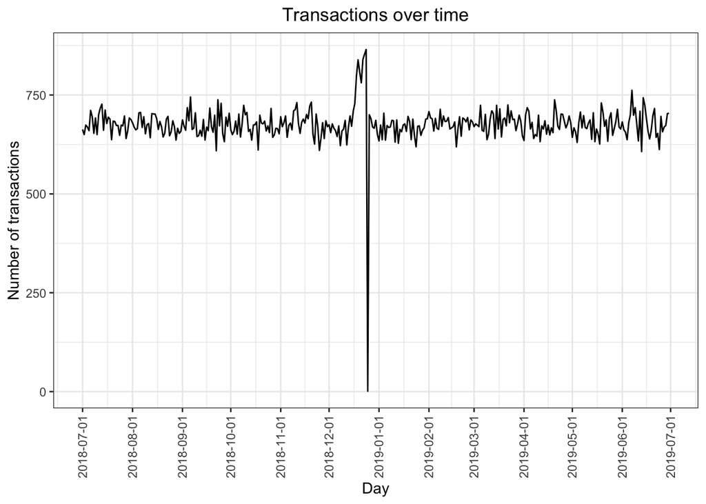

```r
library(ggplot2)
#### Setting plot themes to format graphs
theme_set(theme_bw())
theme_update(plot.title = element_text(hjust = 0.5))
#### Plot transactions over time
ggplot(transactions_per_date, aes(x = as.Date(transactions_per_date), y = N)) +
 geom_line() +
 labs(x = "Day", y = "Number of transactions", title = "Transactions over time") +
 scale_x_date(breaks = "1 month") +
 theme(axis.text.x = element_text(angle = 90, vjust = 0.5))
```

#### Filter to December and look at individual days

We can see some anomaly in December. Creating December chart to further investigate.

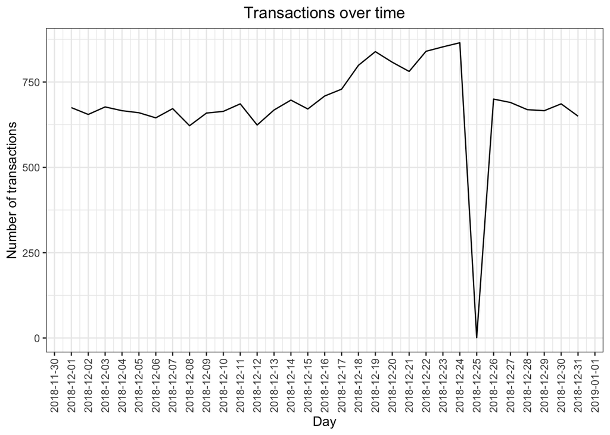

```r
x = subset(transactions_per_date, format.Date(transactions_per_date,"%m")=="12")
ggplot(x, aes(x = as.Date(transactions_per_date), y = N)) +
 geom_line() +
 labs(x = "Day", y = "Number of transactions", title = "Transactions over time") +
 scale_x_date(breaks = "1 day") +
 theme(axis.text.x = element_text(angle = 90, vjust = 0.5))
```

We can see that on Dec 25 we do not have any transaction. Because it was a missing value. Sales got increased until Christmas day and on Christmas day shops were closed.

```r
# removing the Christmas day
trans <- subset(trans,trans$DATE != '2018-12-25')
```

## Feature Engineering

#### Creating new features: Pack size

```r
library(readr)
# creating new Pack size feature in trans by parasing our numbers from product names.
trans[, PACK_SIZE := parse_number(PROD_NAME)]
# Always check your output
# Let's check if the pack sizes look sensible
#.N is a spl variable in data.table used to represent # of observations in a group along with by = pack_size
trans[, .N, PACK_SIZE][order(PACK_SIZE)]
```

```
##     PACK_SIZE     N
##  1:        70  1507
##  2:        90  3008
##  3:       110 22387
##  4:       125  1454
##  5:       134 25102
##  6:       135  3257
##  7:       150 40203
##  8:       160  2970
##  9:       165 15297
## 10:       170 19983
## 11:       175 66390
## 12:       180  1468
## 13:       190  2995
## 14:       200  4473
## 15:       210  6272
## 16:       220  1564
## 17:       250  3169
## 18:       270  6285
## 19:       330 12540
## 20:       380  6416
```

The largest size is 380g and the smallest size is 70g - seems sensible!

#### Histogram of Pack size.

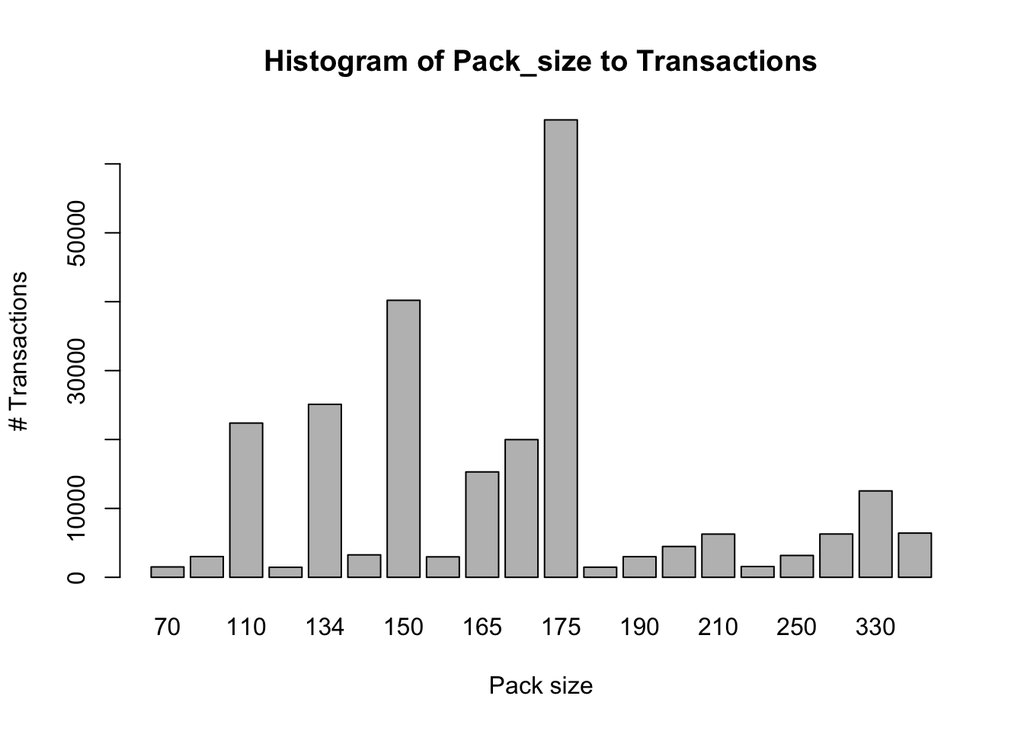

```r
x1 <- trans$PACK_SIZE
x1 <- table(x1)
x1<- data.table(x1)
colnames(x1) <- c('Pack_size','Transactions')

barplot(height = x1$Transactions,
        names.arg = x1$Pack_size,
        main="Histogram of Pack_size to Transactions",
        xlab = "Pack size",
        ylab= "# Transactions")
```

#### Creating new features: Brand_name

```r
#Here we are parsing the first word of the sentence using word() from stringr
trans$Brand_name <- word(trans$PROD_NAME, 1)

#checking brands results
trans[, .N, Brand_name][order(Brand_name)]
```

```
##     Brand_name     N
##  1:     Burger  1564
##  2:        CCs  4551
##  3:    Cheetos  2927
##  4:   Cheezels  4603
##  5:       Cobs  9693
##  6:     Dorito  3183
##  7:    Doritos 22041
##  8:     French  1418
##  9:      Grain  6272
## 10:    GrnWves  1468
## 11:  Infuzions 11057
## 12:     Infzns  3144
## 13:     Kettle 41288
## 14:        NCC  1419
## 15:    Natural  6050
## 16:   Pringles 25102
## 17:        RRD 11894
## 18:        Red  4427
## 19:      Smith  2963
## 20:     Smiths 27390
## 21:      Snbts  1576
## 22:   Sunbites  1432
## 23:      Thins 14075
## 24:   Tostitos  9471
## 25:   Twisties  9454
## 26:   Tyrrells  6442
## 27:         WW 10320
## 28: Woolworths  1516
##     Brand_name     N
```

#### Clean brand names

Some of the brand names look like they are of the same brands - such as RED and RRD, NCC and Natural Chip Co, Smith and Smiths, infuzions and infzns, Snbts and Sunbites, WW and Woolworths, Dorito and Doritos, Grain and GrnWves Let’s combine these together.

```r
#clean brand names
trans[Brand_name == "Red", Brand_name := "RRD"]
trans[Brand_name == "Dorito", Brand_name := "Doritos"]
trans[Brand_name == "GrnWves", Brand_name := "Grain Waves"]
trans[Brand_name == "Grain", Brand_name := "Grain Waves"]
trans[Brand_name == "Natural", Brand_name := "NCC"]
trans[Brand_name == "Smith", Brand_name := "Smiths"]
trans[Brand_name == "Infzns", Brand_name := "Infuzions"]
trans[Brand_name == "Snbts", Brand_name := "Sunbites"]
trans[Brand_name == "Woolworths", Brand_name := "WW"]
```

```r
#checking brands results
trans[, .N, Brand_name][order(Brand_name)]
```

```
##      Brand_name     N
##  1:      Burger  1564
##  2:         CCs  4551
##  3:     Cheetos  2927
##  4:    Cheezels  4603
##  5:        Cobs  9693
##  6:     Doritos 25224
##  7:      French  1418
##  8: Grain Waves  7740
##  9:   Infuzions 14201
## 10:      Kettle 41288
## 11:         NCC  7469
## 12:    Pringles 25102
## 13:         RRD 16321
## 14:      Smiths 30353
## 15:    Sunbites  3008
## 16:       Thins 14075
## 17:    Tostitos  9471
## 18:    Twisties  9454
## 19:    Tyrrells  6442
## 20:          WW 11836
```

#### Loading dataset

```r
cust = read.csv('QVI_purchase_behaviour.csv')
```

### Examining customer data

```r
summary(cust)
```

```
##  LYLTY_CARD_NBR     LIFESTAGE         PREMIUM_CUSTOMER
##  Min.   :   1000   Length:72637       Length:72637
##  1st Qu.:  66202   Class :character   Class :character
##  Median : 134040   Mode  :character   Mode  :character
##  Mean   : 136186
##  3rd Qu.: 203375
##  Max.   :2373711
```

```r
str(cust)
```

```
## 'data.frame':    72637 obs. of  3 variables:
##  $ LYLTY_CARD_NBR  : int  1000 1002 1003 1004 1005 1007 1009 1010 1011 1012 ...
##  $ LIFESTAGE       : chr  "YOUNG SINGLES/COUPLES" "YOUNG SINGLES/COUPLES" "YOUNG FAMILIES" "OLDER SINGLES/COUPLES" ...
##  $ PREMIUM_CUSTOMER: chr  "Premium" "Mainstream" "Budget" "Mainstream" ...
```

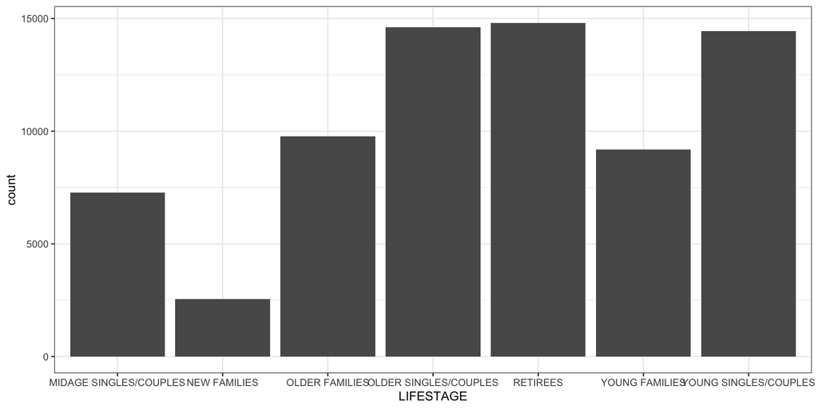

```r
#distribution of lifestage and premium_customer
ggplot(data = cust,aes(x = LIFESTAGE))+geom_histogram(stat = "count")
```

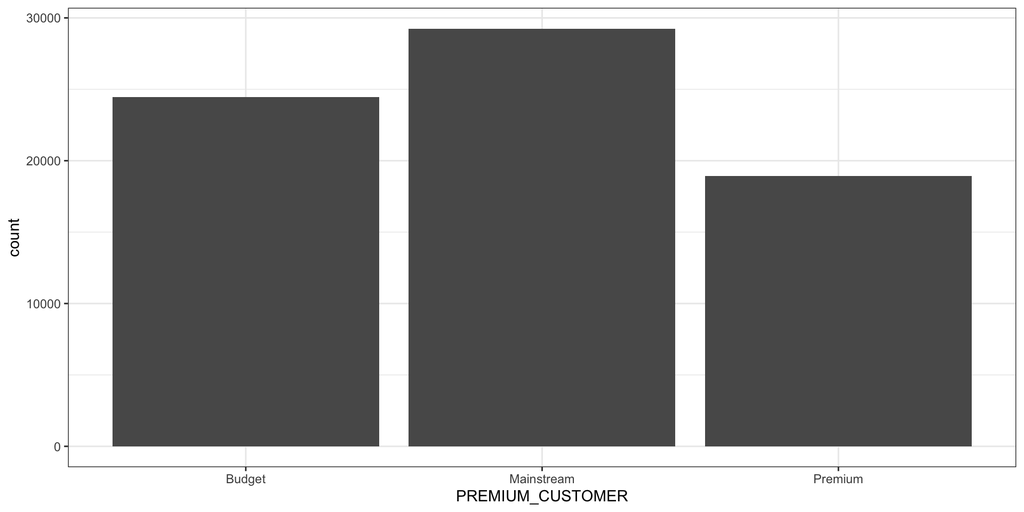

```r
ggplot(data = cust,aes(x = PREMIUM_CUSTOMER))+geom_histogram(stat = "count")
```

#### Merge transaction data to customer data

```r
#### Merge transaction data to customer data
# all.x = T implies full left join
df <- merge(trans, cust, all.x = TRUE)
```

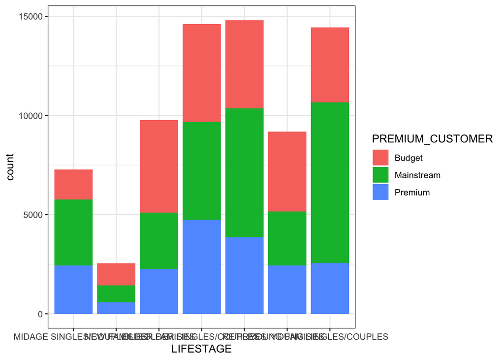

```r
ggplot(data = cust,aes(x = LIFESTAGE,fill = PREMIUM_CUSTOMER))+geom_histogram(stat = "count")
```

Summary and Structure of Customer Data

```r
summary(cust)
```

```
##  LYLTY_CARD_NBR     LIFESTAGE         PREMIUM_CUSTOMER
##  Min.   :   1000   Length:72637       Length:72637
##  1st Qu.:  66202   Class :character   Class :character
##  Median : 134040   Mode  :character   Mode  :character
##  Mean   : 136186
##  3rd Qu.: 203375
##  Max.   :2373711
```

```r
str(cust)
```

```
## 'data.frame':    72637 obs. of  3 variables:
##  $ LYLTY_CARD_NBR  : int  1000 1002 1003 1004 1005 1007 1009 1010 1011 1012 ...
##  $ LIFESTAGE       : chr  "YOUNG SINGLES/COUPLES" "YOUNG SINGLES/COUPLES" "YOUNG FAMILIES" "OLDER SINGLES/COUPLES" ...
##  $ PREMIUM_CUSTOMER: chr  "Premium" "Mainstream" "Budget" "Mainstream" ...
```

```r
#factors
x <- data.frame(cust)
x$LYLTY_CARD_NBR <- as.factor(x$LYLTY_CARD_NBR)
x$LIFESTAGE <- as.factor(x$LIFESTAGE)
x$PREMIUM_CUSTOMER <- as.factor(x$PREMIUM_CUSTOMER)
```

```r
summary(x)
```

```
##  LYLTY_CARD_NBR                   LIFESTAGE       PREMIUM_CUSTOMER
##  1000   :    1   MIDAGE SINGLES/COUPLES: 7275   Budget    :24470
##  1002   :    1   NEW FAMILIES          : 2549   Mainstream:29245
##  1003   :    1   OLDER FAMILIES        : 9780   Premium   :18922
##  1004   :    1   OLDER SINGLES/COUPLES :14609
##  1005   :    1   RETIREES              :14805
##  1007   :    1   YOUNG FAMILIES        : 9178
##  (Other):72631   YOUNG SINGLES/COUPLES :14441
```

```r
str(x)
```

```
## 'data.frame':    72637 obs. of  3 variables:
##  $ LYLTY_CARD_NBR  : Factor w/ 72637 levels "1000","1002",..: 1 2 3 4 5 6 7 8 9 10 ...
##  $ LIFESTAGE       : Factor w/ 7 levels "MIDAGE SINGLES/COUPLES",..: 7 7 6 4 1 7 2 7 4 3 ...
##  $ PREMIUM_CUSTOMER: Factor w/ 3 levels "Budget","Mainstream",..: 3 2 1 2 2 1 3 2 2 2 ...
```

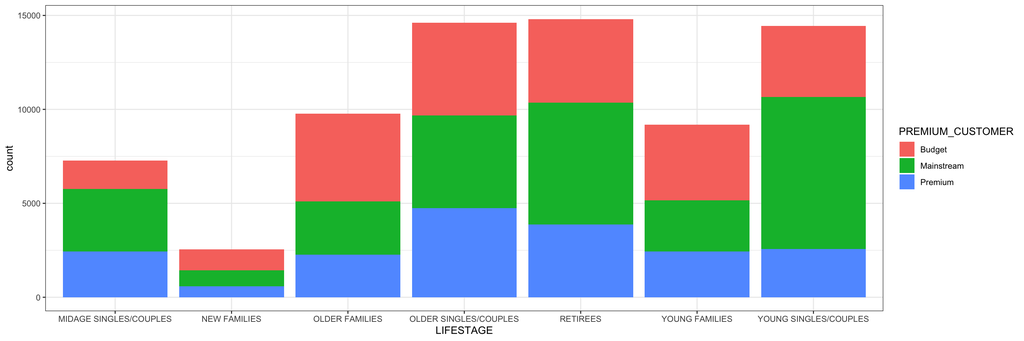

```r
#### Total sales by LIFESTAGE and PREMIUM_CUSTOMER
# Over to you! Calculate the summary of sales by those dimensions and create a plot.
ggplot(data = x,aes(x = LIFESTAGE,fill = PREMIUM_CUSTOMER))+geom_histogram(stat = "count")
```